# Optimal Treatment Analysis

## Outcome Variable

**Outcome Variable:** whz

## Predictor Variables

**Intervention Variable:** single

**Adjustment Set:**

- arm
- W_mage
- meducyrs
- feducyrs
- W_mhtcm
- W_mwtkg
- W_mbmi
- delta_W_mage
- delta_meducyrs
- delta_feducyrs
- delta_W_mhtcm
- delta_W_mwtkg
- delta_W_mbmi

## Stratifying Variables

The analysis was stratified on these variable(s):

- agecat
- studyid
- country

## Data Summary

| agecat | studyid | country | single | n_cell | n |
| --- | --- | --- | --- | --- | --- |
| Birth | ki0047075b-MAL-ED | BANGLADESH | 0 | 215 | 215 |
| Birth | ki0047075b-MAL-ED | BANGLADESH | 1 | 0 | 215 |
| Birth | ki0047075b-MAL-ED | BRAZIL | 0 | 54 | 62 |
| Birth | ki0047075b-MAL-ED | BRAZIL | 1 | 8 | 62 |
| Birth | ki0047075b-MAL-ED | INDIA | 0 | 45 | 45 |
| Birth | ki0047075b-MAL-ED | INDIA | 1 | 0 | 45 |
| Birth | ki0047075b-MAL-ED | NEPAL | 0 | 26 | 26 |
| Birth | ki0047075b-MAL-ED | NEPAL | 1 | 0 | 26 |
| Birth | ki0047075b-MAL-ED | PERU | 0 | 205 | 228 |
| Birth | ki0047075b-MAL-ED | PERU | 1 | 23 | 228 |
| Birth | ki0047075b-MAL-ED | SOUTH AFRICA | 0 | 63 | 120 |
| Birth | ki0047075b-MAL-ED | SOUTH AFRICA | 1 | 57 | 120 |
| Birth | ki0047075b-MAL-ED | TANZANIA, UNITED REPUBLIC OF | 0 | 112 | 115 |
| Birth | ki0047075b-MAL-ED | TANZANIA, UNITED REPUBLIC OF | 1 | 3 | 115 |
| Birth | ki1119695-PROBIT | BELARUS | 0 | 13291 | 13830 |
| Birth | ki1119695-PROBIT | BELARUS | 1 | 539 | 13830 |
| Birth | ki1126311-ZVITAMBO | ZIMBABWE | 0 | 12065 | 12864 |
| Birth | ki1126311-ZVITAMBO | ZIMBABWE | 1 | 799 | 12864 |
| Birth | ki1135781-COHORTS | GUATEMALA | 0 | 654 | 691 |
| Birth | ki1135781-COHORTS | GUATEMALA | 1 | 37 | 691 |
| Birth | ki1135781-COHORTS | INDIA | 0 | 4456 | 4463 |
| Birth | ki1135781-COHORTS | INDIA | 1 | 7 | 4463 |
| Birth | ki1135781-COHORTS | PHILIPPINES | 0 | 2789 | 2860 |
| Birth | ki1135781-COHORTS | PHILIPPINES | 1 | 71 | 2860 |
| Birth | kiGH5241-JiVitA-4 | BANGLADESH | 0 | 2388 | 2393 |
| Birth | kiGH5241-JiVitA-4 | BANGLADESH | 1 | 5 | 2393 |
| 6 months | ki0047075b-MAL-ED | BANGLADESH | 0 | 241 | 241 |
| 6 months | ki0047075b-MAL-ED | BANGLADESH | 1 | 0 | 241 |
| 6 months | ki0047075b-MAL-ED | BRAZIL | 0 | 179 | 209 |
| 6 months | ki0047075b-MAL-ED | BRAZIL | 1 | 30 | 209 |

[output cut: 54 more lines]

The following strata were considered:

- agecat: 24 months, studyid: ki0047075b-MAL-ED, country: BANGLADESH
- agecat: 24 months, studyid: ki0047075b-MAL-ED, country: BRAZIL
- agecat: 24 months, studyid: ki0047075b-MAL-ED, country: INDIA
- agecat: 24 months, studyid: ki0047075b-MAL-ED, country: NEPAL
- agecat: 24 months, studyid: ki0047075b-MAL-ED, country: PERU
- agecat: 24 months, studyid: ki0047075b-MAL-ED, country: SOUTH AFRICA
- agecat: 24 months, studyid: ki0047075b-MAL-ED, country: TANZANIA, UNITED REPUBLIC OF
- agecat: 24 months, studyid: ki1066203-TanzaniaChild2, country: TANZANIA, UNITED REPUBLIC OF
- agecat: 24 months, studyid: ki1119695-PROBIT, country: BELARUS
- agecat: 24 months, studyid: ki1126311-ZVITAMBO, country: ZIMBABWE
- agecat: 24 months, studyid: ki1135781-COHORTS, country: GUATEMALA
- agecat: 24 months, studyid: ki1135781-COHORTS, country: INDIA
- agecat: 24 months, studyid: ki1135781-COHORTS, country: PHILIPPINES
- agecat: 24 months, studyid: kiGH5241-JiVitA-4, country: BANGLADESH
- agecat: 6 months, studyid: ki0047075b-MAL-ED, country: BANGLADESH
- agecat: 6 months, studyid: ki0047075b-MAL-ED, country: BRAZIL
- agecat: 6 months, studyid: ki0047075b-MAL-ED, country: INDIA
- agecat: 6 months, studyid: ki0047075b-MAL-ED, country: NEPAL
- agecat: 6 months, studyid: ki0047075b-MAL-ED, country: PERU
- agecat: 6 months, studyid: ki0047075b-MAL-ED, country: SOUTH AFRICA
- agecat: 6 months, studyid: ki0047075b-MAL-ED, country: TANZANIA, UNITED REPUBLIC OF
- agecat: 6 months, studyid: ki1066203-TanzaniaChild2, country: TANZANIA, UNITED REPUBLIC OF
- agecat: 6 months, studyid: ki1112895-Guatemala BSC, country: GUATEMALA
- agecat: 6 months, studyid: ki1119695-PROBIT, country: BELARUS
- agecat: 6 months, studyid: ki1126311-ZVITAMBO, country: ZIMBABWE
- agecat: 6 months, studyid: ki1135781-COHORTS, country: GUATEMALA
- agecat: 6 months, studyid: ki1135781-COHORTS, country: INDIA
- agecat: 6 months, studyid: ki1135781-COHORTS, country: PHILIPPINES
- agecat: 6 months, studyid: kiGH5241-JiVitA-4, country: BANGLADESH
- agecat: Birth, studyid: ki0047075b-MAL-ED, country: BANGLADESH
- agecat: Birth, studyid: ki0047075b-MAL-ED, country: BRAZIL
- agecat: Birth, studyid: ki0047075b-MAL-ED, country: INDIA
- agecat: Birth, studyid: ki0047075b-MAL-ED, country: NEPAL
- agecat: Birth, studyid: ki0047075b-MAL-ED, country: PERU
- agecat: Birth, studyid: ki0047075b-MAL-ED, country: SOUTH AFRICA
- agecat: Birth, studyid: ki0047075b-MAL-ED, country: TANZANIA, UNITED REPUBLIC OF
- agecat: Birth, studyid: ki1119695-PROBIT, country: BELARUS
- agecat: Birth, studyid: ki1126311-ZVITAMBO, country: ZIMBABWE
- agecat: Birth, studyid: ki1135781-COHORTS, country: GUATEMALA
- agecat: Birth, studyid: ki1135781-COHORTS, country: INDIA
- agecat: Birth, studyid: ki1135781-COHORTS, country: PHILIPPINES
- agecat: Birth, studyid: kiGH5241-JiVitA-4, country: BANGLADESH

### Dropped Strata

Some strata were dropped due to rare outcomes:

- agecat: Birth, studyid: ki0047075b-MAL-ED, country: BANGLADESH
- agecat: Birth, studyid: ki0047075b-MAL-ED, country: INDIA
- agecat: Birth, studyid: ki0047075b-MAL-ED, country: NEPAL
- agecat: Birth, studyid: ki0047075b-MAL-ED, country: TANZANIA, UNITED REPUBLIC OF
- agecat: 6 months, studyid: ki0047075b-MAL-ED, country: BANGLADESH
- agecat: 6 months, studyid: ki0047075b-MAL-ED, country: INDIA
- agecat: 6 months, studyid: ki0047075b-MAL-ED, country: NEPAL
- agecat: 24 months, studyid: ki0047075b-MAL-ED, country: BANGLADESH
- agecat: 24 months, studyid: ki0047075b-MAL-ED, country: INDIA
- agecat: 24 months, studyid: ki0047075b-MAL-ED, country: NEPAL
- agecat: 24 months, studyid: ki1066203-TanzaniaChild2, country: TANZANIA, UNITED REPUBLIC OF

## Methods Detail

We’re interested in the causal parameters $E[Y_a]$ for all values of $a \in \mathcal{A}$. These parameters represent the mean outcome if, possibly contrary to fact, we intervened to set all units to have $A=a$. Under the randomization and positivity assumptions, these are identified by the statistical parameters $\psi_a=E_W[E_{Y|A,W}(Y|A=a,W)]$. In addition, we’re interested in the mean of $Y$, $E[Y]$ under no intervention (the observed mean). We will estimate these parameters by using SuperLearner to fit the relevant likelihood factors – $E_{Y|A,W}(Y|A=a,W)$ and $p(A=a|W)$, and then updating our likelihood fit using a joint TMLE.

For unadjusted analyses ($W=\{\}$), initial likelihoods were estimated using Lrnr_glm to estimate the simple $E(Y|A)$ and Lrnr_mean to estimate $p(A)$. For adjusted analyses, a small library containing Lrnr_glmnet, Lrnr_xgboost, and Lrnr_mean was used.

Having estimated these parameters, we will then use the delta method to estimate relative risks and attributable risks relative to a prespecified baseline level of $A$.

# Results Detail

## Results Plots

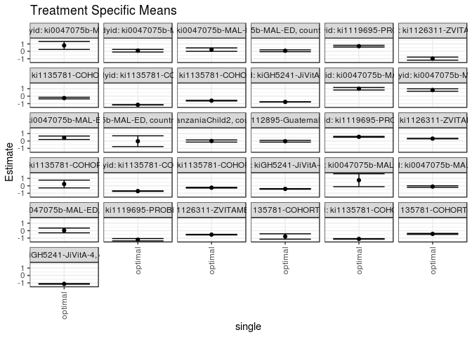

## Results Table

### Parameter: TSM

| agecat | studyid | country | intervention_level | baseline_level | estimate | ci_lower | ci_upper |
| --- | --- | --- | --- | --- | --- | --- | --- |
| Birth | ki0047075b-MAL-ED | BRAZIL | optimal | observed | 0.7555842 | -0.1178823 | 1.6290507 |
| Birth | ki0047075b-MAL-ED | PERU | optimal | observed | -0.1013451 | -0.2054629 | 0.0027728 |
| Birth | ki0047075b-MAL-ED | SOUTH AFRICA | optimal | observed | 0.0279005 | -0.2909662 | 0.3467673 |
| Birth | ki1119695-PROBIT | BELARUS | optimal | observed | -1.2140689 | -1.3707623 | -1.0573755 |
| Birth | ki1126311-ZVITAMBO | ZIMBABWE | optimal | observed | -0.5369910 | -0.5751231 | -0.4988589 |
| Birth | ki1135781-COHORTS | GUATEMALA | optimal | observed | -0.7827224 | -1.1425359 | -0.4229089 |
| Birth | ki1135781-COHORTS | INDIA | optimal | observed | -1.1143067 | -1.1497493 | -1.0788640 |
| Birth | ki1135781-COHORTS | PHILIPPINES | optimal | observed | -0.4364724 | -0.5072117 | -0.3657330 |
| Birth | kiGH5241-JiVitA-4 | BANGLADESH | optimal | observed | -1.1321907 | -1.1725967 | -1.0917847 |
| 6 months | ki0047075b-MAL-ED | BRAZIL | optimal | observed | 1.0007928 | 0.8256037 | 1.1759819 |
| 6 months | ki0047075b-MAL-ED | PERU | optimal | observed | 0.8227228 | 0.6560360 | 0.9894095 |
| 6 months | ki0047075b-MAL-ED | SOUTH AFRICA | optimal | observed | 0.4368895 | 0.2059906 | 0.6677883 |
| 6 months | ki0047075b-MAL-ED | TANZANIA, UNITED REPUBLIC OF | optimal | observed | -0.0309238 | -0.7608535 | 0.6990059 |
| 6 months | ki1066203-TanzaniaChild2 | TANZANIA, UNITED REPUBLIC OF | optimal | observed | -0.0022775 | -0.1475592 | 0.1430041 |
| 6 months | ki1112895-Guatemala BSC | GUATEMALA | optimal | observed | -0.0323927 | -0.1536228 | 0.0888373 |
| 6 months | ki1119695-PROBIT | BELARUS | optimal | observed | 0.5631664 | 0.5036699 | 0.6226628 |
| 6 months | ki1126311-ZVITAMBO | ZIMBABWE | optimal | observed | 0.3239332 | 0.2889038 | 0.3589626 |
| 6 months | ki1135781-COHORTS | GUATEMALA | optimal | observed | 0.2445536 | -0.2791834 | 0.7682906 |
| 6 months | ki1135781-COHORTS | INDIA | optimal | observed | -0.7098994 | -0.7430332 | -0.6767657 |
| 6 months | ki1135781-COHORTS | PHILIPPINES | optimal | observed | -0.2509116 | -0.3018928 | -0.1999303 |
| 6 months | kiGH5241-JiVitA-4 | BANGLADESH | optimal | observed | -0.4152420 | -0.4528513 | -0.3776326 |
| 24 months | ki0047075b-MAL-ED | BRAZIL | optimal | observed | 0.7912395 | 0.2598273 | 1.3226516 |
| 24 months | ki0047075b-MAL-ED | PERU | optimal | observed | 0.0843173 | -0.0938244 | 0.2624590 |
| 24 months | ki0047075b-MAL-ED | SOUTH AFRICA | optimal | observed | 0.2291662 | 0.0000376 | 0.4582948 |
| 24 months | ki0047075b-MAL-ED | TANZANIA, UNITED REPUBLIC OF | optimal | observed | 0.0766771 | -0.0481415 | 0.2014956 |
| 24 months | ki1119695-PROBIT | BELARUS | optimal | observed | 0.6933392 | 0.5766236 | 0.8100548 |
| 24 months | ki1126311-ZVITAMBO | ZIMBABWE | optimal | observed | -0.9856648 | -1.1929734 | -0.7783561 |
| 24 months | ki1135781-COHORTS | GUATEMALA | optimal | observed | -0.2569957 | -0.3652972 | -0.1486941 |
| 24 months | ki1135781-COHORTS | INDIA | optimal | observed | -1.1682295 | -1.1929082 | -1.1435508 |
| 24 months | ki1135781-COHORTS | PHILIPPINES | optimal | observed | -0.6077837 | -0.6516542 | -0.5639131 |
| 24 months | kiGH5241-JiVitA-4 | BANGLADESH | optimal | observed | -0.7762658 | -0.7916821 | -0.7608495 |

### Parameter: E(Y)

| agecat | studyid | country | intervention_level | baseline_level | estimate | ci_lower | ci_upper |
| --- | --- | --- | --- | --- | --- | --- | --- |
| Birth | ki0047075b-MAL-ED | BRAZIL | observed | observed | 0.4029032 | 0.0896793 | 0.7161272 |
| Birth | ki0047075b-MAL-ED | PERU | observed | observed | -0.0520175 | -0.1725298 | 0.0684947 |
| Birth | ki0047075b-MAL-ED | SOUTH AFRICA | observed | observed | -0.1925833 | -0.4053570 | 0.0201904 |
| Birth | ki1119695-PROBIT | BELARUS | observed | observed | -1.1448633 | -1.3544229 | -0.9353037 |
| Birth | ki1126311-ZVITAMBO | ZIMBABWE | observed | observed | -0.5148609 | -0.5407634 | -0.4889583 |
| Birth | ki1135781-COHORTS | GUATEMALA | observed | observed | -1.0552243 | -1.1617873 | -0.9486614 |
| Birth | ki1135781-COHORTS | INDIA | observed | observed | -0.9765068 | -1.0113301 | -0.9416835 |
| Birth | ki1135781-COHORTS | PHILIPPINES | observed | observed | -0.7377902 | -0.7844819 | -0.6910986 |
| Birth | kiGH5241-JiVitA-4 | BANGLADESH | observed | observed | -0.6888174 | -0.7412201 | -0.6364147 |
| 6 months | ki0047075b-MAL-ED | BRAZIL | observed | observed | 0.9720774 | 0.8078144 | 1.1363403 |
| 6 months | ki0047075b-MAL-ED | PERU | observed | observed | 1.0528816 | 0.9313005 | 1.1744626 |
| 6 months | ki0047075b-MAL-ED | SOUTH AFRICA | observed | observed | 0.5421785 | 0.3900443 | 0.6943126 |
| 6 months | ki0047075b-MAL-ED | TANZANIA, UNITED REPUBLIC OF | observed | observed | 0.5362213 | 0.4049390 | 0.6675036 |
| 6 months | ki1066203-TanzaniaChild2 | TANZANIA, UNITED REPUBLIC OF | observed | observed | 0.0797577 | 0.0268998 | 0.1326156 |
| 6 months | ki1112895-Guatemala BSC | GUATEMALA | observed | observed | -0.0568833 | -0.1722874 | 0.0585208 |
| 6 months | ki1119695-PROBIT | BELARUS | observed | observed | 0.5792439 | 0.5193388 | 0.6391490 |
| 6 months | ki1126311-ZVITAMBO | ZIMBABWE | observed | observed | 0.3108992 | 0.2851818 | 0.3366167 |
| 6 months | ki1135781-COHORTS | GUATEMALA | observed | observed | 0.1920134 | 0.1173734 | 0.2666534 |
| 6 months | ki1135781-COHORTS | INDIA | observed | observed | -0.7104795 | -0.7428008 | -0.6781581 |
| 6 months | ki1135781-COHORTS | PHILIPPINES | observed | observed | -0.2936948 | -0.3352840 | -0.2521057 |
| 6 months | kiGH5241-JiVitA-4 | BANGLADESH | observed | observed | -0.3904664 | -0.4277855 | -0.3531473 |
| 24 months | ki0047075b-MAL-ED | BRAZIL | observed | observed | 0.4626233 | 0.2567495 | 0.6684971 |
| 24 months | ki0047075b-MAL-ED | PERU | observed | observed | 0.1111982 | -0.0118399 | 0.2342362 |
| 24 months | ki0047075b-MAL-ED | SOUTH AFRICA | observed | observed | 0.4090301 | 0.2879441 | 0.5301161 |
| 24 months | ki0047075b-MAL-ED | TANZANIA, UNITED REPUBLIC OF | observed | observed | 0.0547975 | -0.0703378 | 0.1799328 |
| 24 months | ki1119695-PROBIT | BELARUS | observed | observed | 0.6874295 | 0.5756922 | 0.7991668 |
| 24 months | ki1126311-ZVITAMBO | ZIMBABWE | observed | observed | -1.1797222 | -1.2787189 | -1.0807256 |
| 24 months | ki1135781-COHORTS | GUATEMALA | observed | observed | -0.2796964 | -0.3351582 | -0.2242346 |
| 24 months | ki1135781-COHORTS | INDIA | observed | observed | -0.6594122 | -0.6925753 | -0.6262491 |
| 24 months | ki1135781-COHORTS | PHILIPPINES | observed | observed | -0.6100579 | -0.6471813 | -0.5729344 |
| 24 months | kiGH5241-JiVitA-4 | BANGLADESH | observed | observed | -1.2239898 | -1.2559235 | -1.1920562 |

### Parameter: PAR

| agecat | studyid | country | intervention_level | baseline_level | estimate | ci_lower | ci_upper |
| --- | --- | --- | --- | --- | --- | --- | --- |
| Birth | ki0047075b-MAL-ED | BRAZIL | optimal | observed | -0.3526810 | -1.1759724 | 0.4706104 |
| Birth | ki0047075b-MAL-ED | PERU | optimal | observed | 0.0493275 | -0.0793958 | 0.1780508 |
| Birth | ki0047075b-MAL-ED | SOUTH AFRICA | optimal | observed | -0.2204839 | -0.4420561 | 0.0010883 |
| Birth | ki1119695-PROBIT | BELARUS | optimal | observed | 0.0692056 | -0.0807408 | 0.2191520 |
| Birth | ki1126311-ZVITAMBO | ZIMBABWE | optimal | observed | 0.0221302 | -0.0054546 | 0.0497149 |
| Birth | ki1135781-COHORTS | GUATEMALA | optimal | observed | -0.2725019 | -0.6173350 | 0.0723312 |
| Birth | ki1135781-COHORTS | INDIA | optimal | observed | 0.1377998 | 0.1167798 | 0.1588198 |
| Birth | ki1135781-COHORTS | PHILIPPINES | optimal | observed | -0.3013178 | -0.3691451 | -0.2334905 |
| Birth | kiGH5241-JiVitA-4 | BANGLADESH | optimal | observed | 0.4433733 | 0.3852966 | 0.5014501 |
| 6 months | ki0047075b-MAL-ED | BRAZIL | optimal | observed | -0.0287155 | -0.1003591 | 0.0429282 |
| 6 months | ki0047075b-MAL-ED | PERU | optimal | observed | 0.2301588 | 0.1077889 | 0.3525288 |
| 6 months | ki0047075b-MAL-ED | SOUTH AFRICA | optimal | observed | 0.1052890 | -0.0962910 | 0.3068690 |
| 6 months | ki0047075b-MAL-ED | TANZANIA, UNITED REPUBLIC OF | optimal | observed | 0.5671451 | -0.1523650 | 1.2866553 |
| 6 months | ki1066203-TanzaniaChild2 | TANZANIA, UNITED REPUBLIC OF | optimal | observed | 0.0820352 | -0.0510761 | 0.2151466 |
| 6 months | ki1112895-Guatemala BSC | GUATEMALA | optimal | observed | -0.0244905 | -0.0658362 | 0.0168551 |
| 6 months | ki1119695-PROBIT | BELARUS | optimal | observed | 0.0160775 | 0.0052970 | 0.0268581 |
| 6 months | ki1126311-ZVITAMBO | ZIMBABWE | optimal | observed | -0.0130340 | -0.0371891 | 0.0111211 |
| 6 months | ki1135781-COHORTS | GUATEMALA | optimal | observed | -0.0525402 | -0.5631234 | 0.4580431 |
| 6 months | ki1135781-COHORTS | INDIA | optimal | observed | -0.0005800 | -0.0018913 | 0.0007313 |
| 6 months | ki1135781-COHORTS | PHILIPPINES | optimal | observed | -0.0427833 | -0.0755156 | -0.0100510 |
| 6 months | kiGH5241-JiVitA-4 | BANGLADESH | optimal | observed | 0.0247756 | 0.0068592 | 0.0426920 |
| 24 months | ki0047075b-MAL-ED | BRAZIL | optimal | observed | -0.3286162 | -0.8190590 | 0.1618267 |
| 24 months | ki0047075b-MAL-ED | PERU | optimal | observed | 0.0268809 | -0.0957968 | 0.1495585 |
| 24 months | ki0047075b-MAL-ED | SOUTH AFRICA | optimal | observed | 0.1798639 | -0.0059975 | 0.3657253 |
| 24 months | ki0047075b-MAL-ED | TANZANIA, UNITED REPUBLIC OF | optimal | observed | -0.0218796 | -0.0532151 | 0.0094560 |
| 24 months | ki1119695-PROBIT | BELARUS | optimal | observed | -0.0059097 | -0.0193759 | 0.0075564 |
| 24 months | ki1126311-ZVITAMBO | ZIMBABWE | optimal | observed | -0.1940574 | -0.4028905 | 0.0147756 |
| 24 months | ki1135781-COHORTS | GUATEMALA | optimal | observed | -0.0227007 | -0.1152317 | 0.0698303 |
| 24 months | ki1135781-COHORTS | INDIA | optimal | observed | 0.5088173 | 0.4767180 | 0.5409166 |
| 24 months | ki1135781-COHORTS | PHILIPPINES | optimal | observed | -0.0022742 | -0.0243430 | 0.0197946 |
| 24 months | kiGH5241-JiVitA-4 | BANGLADESH | optimal | observed | -0.4477240 | -0.4833560 | -0.4120921 |